# Introduction to Machine Learning in Python

### What is machine learning

> Machine learning algorithms build a mathematical model based on sample data, known as "training data", in order to make predictions or decisions without being explicitly programmed to do so. - Wikipedia 2020

We try to create something that learns by itself, given some data, to do things.

## How did it all start

[figure not shown]

We'll discuss machine learning here. If you are interested in Deep Learning, invite me over another time again :)

# How does it compare with programming?

### The traditional programming structure

[figure not shown]

### The structure for machine learning

[figure not shown]

### How do we get the right weights (parameters)?

[figure not shown]

### When using in a live system

[figure not shown]

# What are we looking at?

These slides are created with a jupyter notebook, which you'll see as well! Jupyter notebooks are a REPL(Read–eval–print loop)-based interface that is the main tool of data scientists. It allows for rapid experimentation and easy plotting! It is build on IPython, which has a lot of cool things as well!

```python
import numpy as np
??np.arange
```

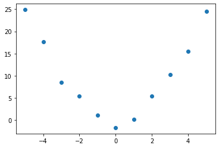

```python
import matplotlib.pyplot as plt
x = np.arange(-5, 6)
y = x**2 + np.random.normal(size=(len(x)))
plt.show(plt.scatter(x, y))
```

```python
import plotly.express as px
px.scatter(y=y, x=x)
```

[interactive chart not shown]

# Lets start with some data!

We're gonna predict the strain of grape plant that wine was made from!

```python
wine_raw = load_wine(as_frame=True)
wine = wine_raw['frame']
print(wine_raw.target_names)
wine.sample(5)
```

```
['class_0' 'class_1' 'class_2']
```

|  | alcohol | malic_acid | ash | alcalinity_of_ash | magnesium | total_phenols | flavanoids | nonflavanoid_phenols | proanthocyanins | color_intensity | hue | od280/od315_of_diluted_wines | proline | target |
| --- | --- | --- | --- | --- | --- | --- | --- | --- | --- | --- | --- | --- | --- | --- |
| 169 | 13.40 | 4.60 | 2.86 | 25.0 | 112.0 | 1.98 | 0.96 | 0.27 | 1.11 | 8.50 | 0.67 | 1.92 | 630.0 | 2 |
| 13 | 14.75 | 1.73 | 2.39 | 11.4 | 91.0 | 3.10 | 3.69 | 0.43 | 2.81 | 5.40 | 1.25 | 2.73 | 1150.0 | 0 |
| 148 | 13.32 | 3.24 | 2.38 | 21.5 | 92.0 | 1.93 | 0.76 | 0.45 | 1.25 | 8.42 | 0.55 | 1.62 | 650.0 | 2 |
| 155 | 13.17 | 5.19 | 2.32 | 22.0 | 93.0 | 1.74 | 0.63 | 0.61 | 1.55 | 7.90 | 0.60 | 1.48 | 725.0 | 2 |
| 134 | 12.51 | 1.24 | 2.25 | 17.5 | 85.0 | 2.00 | 0.58 | 0.60 | 1.25 | 5.45 | 0.75 | 1.51 | 650.0 | 2 |

**data/independent variable**: All columns except the column we want to predict.

**target/dependent variable**: The thing we want to predict, so the `target` column. This value "depends" on the rest of the data.

## So lets train a machine learning model!

```python
dt = DecisionTreeClassifier(max_depth=2)
dt.fit(wine.drop('target', axis=1), wine.target)
print(f'Accuracy: {dt.score(wine.drop("target", axis=1), wine.target):.02f}')
```

```
Accuracy: 0.92
```

**Accuracy**: how many predictions were correct? -> sum(1=1, 2=2, 3=3)/total

## What is a Decision Tree?

Machine learning algorithm that splits on values of certain columns to predict answers. For example, what kind of contacts is someone wearing? Or, what strain of plant was used for a wine?

Why do we like this?

- Doesn't require a lot of feature engineering -> can use the data as is.
- Is very explainable and transparant.

[figure not shown]

```python
tree_viz
```

[figure not shown]

And we can show the importance of each feature

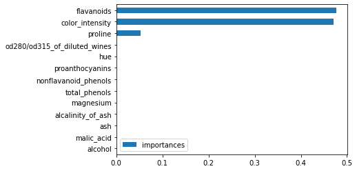

```python
(pd.DataFrame({'importances': dt.feature_importances_}, index=wine.drop('target', axis=1).columns)
     .sort_values('importances', ascending=True)
     .plot(kind='barh')
)
```

# Easy, right?

[figure not shown]

We might need to do a little due diligence.

## How do we know our model is any good?

Our model trains on all data and we are also evaluating using that data! That doens't work, the model has already seen that data! So we need a separate data set to evaluate our model.

We split our data into a *training set* and a *test set*. The *test set* is some percentage of the total data set. We will evaluate our model on the *test set*.

[figure not shown]

```python
x_train, x_test, y_train, y_test = train_test_split(wine.drop('target', axis=1), wine[['target']], test_size=0.2, shuffle=False)
```

```python
x_train.shape, y_train.shape, x_test.shape, y_test.shape
```

```
((142, 13), (142, 1), (36, 13), (36, 1))
```

```python
x_train.head(2)
```

|  | alcohol | malic_acid | ash | alcalinity_of_ash | magnesium | total_phenols | flavanoids | nonflavanoid_phenols | proanthocyanins | color_intensity | hue | od280/od315_of_diluted_wines | proline |
| --- | --- | --- | --- | --- | --- | --- | --- | --- | --- | --- | --- | --- | --- |
| 0 | 14.23 | 1.71 | 2.43 | 15.6 | 127.0 | 2.80 | 3.06 | 0.28 | 2.29 | 5.64 | 1.04 | 3.92 | 1065.0 |
| 1 | 13.20 | 1.78 | 2.14 | 11.2 | 100.0 | 2.65 | 2.76 | 0.26 | 1.28 | 4.38 | 1.05 | 3.40 | 1050.0 |

```python
y_train.head(2)
```

|  | target |
| --- | --- |
| 0 | 0 |
| 1 | 0 |

```python
dt = DecisionTreeClassifier(max_depth=2, random_state=8)
dt.fit(x_train, y_train)
print(f'Test set accuracy: {dt.score(x_test, y_test):.02f}')
```

```
Test set accuracy: 0.72
```

Oh no! Our accuracy dropped! So it performs a bit worse on data it has never seen.

Well, that ok, since it is still pretty high and we were only allowing the model to use two decisions.

**What if we allow it to do more?**

```python
dt = DecisionTreeClassifier(max_depth=3, random_state=8)
dt.fit(x_train, y_train)
print(f'Test set accuracy: {dt.score(x_test, y_test):.02f}')
```

```
Test set accuracy: 0.92
```

```python
dt = DecisionTreeClassifier(max_depth=5, random_state=8)
dt.fit(x_train, y_train)
print(f'Test set accuracy: {dt.score(x_test, y_test):.02f}')
```

```
Test set accuracy: 0.89
```

### Accuracy goes down!?

```
Test set accuracy with max depth of 1: 0.00
Test set accuracy with max depth of 2: 0.72
Test set accuracy with max depth of 3: 0.92
Test set accuracy with max depth of 5: 0.89
```

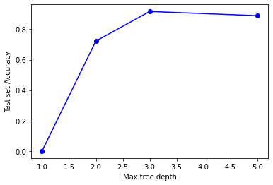

```python
accuracies = []
max_depths = [1, 2, 3, 5]
for max_depth in max_depths:
    dt = DecisionTreeClassifier(max_depth=max_depth, random_state=8)
    dt.fit(x_train, y_train)
    accuracy = dt.score(x_test, y_test)
    accuracies.append(accuracy)
    print(f'Test set accuracy with max depth of {max_depth}: {accuracy:.02f}')
plt.plot(max_depths, accuracies, 'bo-')
plt.xlabel('Max tree depth')
plt.ylabel('Test set Accuracy')
plt.show()
```

# Overfitting

A model or analysis that corresponds too closely or exactly with a particular set of data, and may therefor fail to generalize to new data points. The model is fitting to noise in the train set (not the thing we want to model).

[figure not shown]

We can try to prevent overfitting by:

1. Using more data (not always an option)
2. Reduce parameters in the model (Like reducing max depth)
3. Regularize the model (Like requiring multiple data points for each leaf-node)

# Stepping back a bit

We have seen:

1. What a decision tree is
2. What a train and test set are
3. What overfitting is

To give some extra context:

- This was a supervised machine learning problem
- It was a classification task

# Types of machine learning

1. **Supervised learning - We have labels (Strain of grape plant)**
2. Unsupervised learning - We don't have labels (We want to find similar data points)
3. Reinforcement learning - The algorithms learns from its own predictions (We want to play a game)

## Types of supervised learning:

1. **Classification** - Predict one of several classes. (Strain of grape plant, Animal, gender, etc.)
2. Regression - Predict a continuous value. (Price, weight, height, etc)

# Going a bit deeper: Random Forests

What other machine learning algorithms are there? We have the big brother of decision trees: random forests! They reduce the problem of overfitting of a single decision tree.

- Consist of a large number of individual decision trees (Ensemble)
- Are fit to a random subset of the training dataset (Boosted Aggregation, or bagging)
- Predict with the mode or mean of the predictions from each tree.

[figure not shown]

> "The low correlation between models is the key. Uncorrelated models can produce ensemble predictions that are more accurate than any of the individual predictions. (...) The reason for this wonderful effect is that the trees protect each other from their individual errors." - Tony Yiu ([Understanding Random Forests](https://towardsdatascience.com/understanding-random-forest-58381e0602d2))

```python
rfs = RandomForestClassifier(n_estimators=5, max_depth=2, random_state=9)
rfs.fit(x_train, y_train)
print('Test set acuraccy of decision tree with max-depth 2: 0.72')
print(f'Test set accuracy: {rfs.score(x_test, y_test):.02f}')
```

```
Test set acuraccy of decision tree with max-depth 2: 0.72
Test set accuracy: 0.89
```

```
Test set accuracy with 1 trees: 0.5000
Test set accuracy with 3 trees: 0.7778
Test set accuracy with 5 trees: 0.7500
Test set accuracy with 10 trees: 0.5278
```

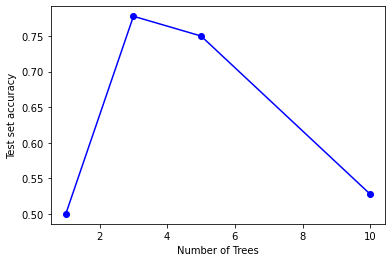

```python
accuracies = []
n_trees = [1, 3, 5, 10]
for n_tree in n_trees:
    rfs = RandomForestClassifier(n_estimators=n_tree, max_depth=2)
    rfs.fit(x_train, y_train.values.reshape(-1))
    accuracy = rfs.score(x_test, y_test)
    accuracies.append(accuracy)
    print(f'Test set accuracy with {n_tree} trees: {accuracy:.04f}')
plt.plot(n_trees, accuracies, 'bo-')
plt.xlabel('Number of Trees')
plt.ylabel('Test set accuracy')
plt.show()
```

# Lets make it a bit more interesting

This was only done on a very simple datasetand we have only looking at the modelling, and nothing else around.

[figure not shown]

The following example is from a course on ML from the University of San Fransisco. They have a great teacher, Jeremy Howard, who does really well code-first approached to machine learning and deep learning.

- Their lesson on this dataset is at https://github.com/fastai/fastai/blob/master/courses/ml1/lesson1-rf.ipynb.
- Find more of their work on fast.ai

```python
bulldozer_raw = pd.read_csv('Train.csv', parse_dates=['saledate'], low_memory=False)[:5000]
```

```python
display_all(bulldozer_raw[:30])
```

|  | SalesID | SalePrice | MachineID | ModelID | datasource | auctioneerID | YearMade | MachineHoursCurrentMeter | UsageBand | saledate | fiModelDesc | fiBaseModel | fiSecondaryDesc | fiModelSeries | fiModelDescriptor | ProductSize | fiProductClassDesc | state | ProductGroup | ProductGroupDesc | Drive_System | Enclosure | Forks | Pad_Type | Ride_Control | Stick | Transmission | Turbocharged | Blade_Extension | … |
| --- | --- | --- | --- | --- | --- | --- | --- | --- | --- | --- | --- | --- | --- | --- | --- | --- | --- | --- | --- | --- | --- | --- | --- | --- | --- | --- | --- | --- | --- | --- |
| 0 | 1139246 | 66000 | 999089 | 3157 | 121 | 3.0 | 2004 | 68.0 | Low | 2006-11-16 | 521D | 521 | D | NaN | NaN | NaN | Wheel Loader - 110.0 to 120.0 Horsepower | Alabama | WL | Wheel Loader | NaN | EROPS w AC | None or Unspecified | NaN | None or Unspecified | NaN | NaN | NaN | NaN | … |
| 1 | 1139248 | 57000 | 117657 | 77 | 121 | 3.0 | 1996 | 4640.0 | Low | 2004-03-26 | 950FII | 950 | F | II | NaN | Medium | Wheel Loader - 150.0 to 175.0 Horsepower | North Carolina | WL | Wheel Loader | NaN | EROPS w AC | None or Unspecified | NaN | None or Unspecified | NaN | NaN | NaN | NaN | … |
| 2 | 1139249 | 10000 | 434808 | 7009 | 121 | 3.0 | 2001 | 2838.0 | High | 2004-02-26 | 226 | 226 | NaN | NaN | NaN | NaN | Skid Steer Loader - 1351.0 to 1601.0 Lb Operat... | New York | SSL | Skid Steer Loaders | NaN | OROPS | None or Unspecified | NaN | NaN | NaN | NaN | NaN | NaN | … |
| 3 | 1139251 | 38500 | 1026470 | 332 | 121 | 3.0 | 2001 | 3486.0 | High | 2011-05-19 | PC120-6E | PC120 | NaN | -6E | NaN | Small | Hydraulic Excavator, Track - 12.0 to 14.0 Metr... | Texas | TEX | Track Excavators | NaN | EROPS w AC | NaN | NaN | NaN | NaN | NaN | NaN | NaN | … |
| 4 | 1139253 | 11000 | 1057373 | 17311 | 121 | 3.0 | 2007 | 722.0 | Medium | 2009-07-23 | S175 | S175 | NaN | NaN | NaN | NaN | Skid Steer Loader - 1601.0 to 1751.0 Lb Operat... | New York | SSL | Skid Steer Loaders | NaN | EROPS | None or Unspecified | NaN | NaN | NaN | NaN | NaN | NaN | … |
| 5 | 1139255 | 26500 | 1001274 | 4605 | 121 | 3.0 | 2004 | 508.0 | Low | 2008-12-18 | 310G | 310 | G | NaN | NaN | NaN | Backhoe Loader - 14.0 to 15.0 Ft Standard Digg... | Arizona | BL | Backhoe Loaders | Four Wheel Drive | OROPS | None or Unspecified | None or Unspecified | No | Extended | Powershuttle | None or Unspecified | NaN | … |
| 6 | 1139256 | 21000 | 772701 | 1937 | 121 | 3.0 | 1993 | 11540.0 | High | 2004-08-26 | 790ELC | 790 | E | NaN | LC | Large / Medium | Hydraulic Excavator, Track - 21.0 to 24.0 Metr... | Florida | TEX | Track Excavators | NaN | EROPS | NaN | NaN | NaN | NaN | NaN | NaN | NaN | … |
| 7 | 1139261 | 27000 | 902002 | 3539 | 121 | 3.0 | 2001 | 4883.0 | High | 2005-11-17 | 416D | 416 | D | NaN | NaN | NaN | Backhoe Loader - 14.0 to 15.0 Ft Standard Digg... | Illinois | BL | Backhoe Loaders | Four Wheel Drive | OROPS | None or Unspecified | Reversible | No | Standard | Standard | Yes | NaN | … |
| 8 | 1139272 | 21500 | 1036251 | 36003 | 121 | 3.0 | 2008 | 302.0 | Low | 2009-08-27 | 430HAG | 430 | HAG | NaN | NaN | Mini | Hydraulic Excavator, Track - 3.0 to 4.0 Metric... | Texas | TEX | Track Excavators | NaN | EROPS | NaN | NaN | NaN | NaN | NaN | NaN | NaN | … |
| 9 | 1139275 | 65000 | 1016474 | 3883 | 121 | 3.0 | 1000 | 20700.0 | Medium | 2007-08-09 | 988B | 988 | B | NaN | NaN | Large | Wheel Loader - 350.0 to 500.0 Horsepower | Florida | WL | Wheel Loader | NaN | EROPS w AC | None or Unspecified | NaN | None or Unspecified | NaN | NaN | NaN | NaN | … |
| 10 | 1139278 | 24000 | 1024998 | 4605 | 121 | 3.0 | 2004 | 1414.0 | Medium | 2008-08-21 | 310G | 310 | G | NaN | NaN | NaN | Backhoe Loader - 14.0 to 15.0 Ft Standard Digg... | Oregon | BL | Backhoe Loaders | Four Wheel Drive | OROPS | None or Unspecified | Street | No | Standard | Standard | None or Unspecified | NaN | … |
| 11 | 1139282 | 22500 | 319906 | 5255 | 121 | 3.0 | 1998 | 2764.0 | Low | 2006-08-24 | D31E | D31 | E | NaN | NaN | NaN | Track Type Tractor, Dozer - 20.0 to 75.0 Horse... | Ohio | TTT | Track Type Tractors | NaN | EROPS w AC | NaN | NaN | NaN | NaN | Standard | NaN | NaN | … |
| 12 | 1139283 | 36000 | 1052214 | 2232 | 121 | 3.0 | 1998 | 0.0 | NaN | 2005-10-20 | PC200LC6 | PC200 | NaN | LC | 6 | Large / Medium | Hydraulic Excavator, Track - 19.0 to 21.0 Metr... | Ohio | TEX | Track Excavators | NaN | EROPS | NaN | NaN | NaN | NaN | NaN | NaN | NaN | … |
| 13 | 1139284 | 30500 | 1068082 | 3542 | 121 | 3.0 | 2001 | 1921.0 | Medium | 2006-01-26 | 420D | 420 | D | NaN | NaN | NaN | Backhoe Loader - 14.0 to 15.0 Ft Standard Digg... | Texas | BL | Backhoe Loaders | Four Wheel Drive | OROPS | None or Unspecified | None or Unspecified | No | Standard | Standard | None or Unspecified | NaN | … |
| 14 | 1139290 | 28000 | 1058450 | 5162 | 121 | 3.0 | 2004 | 320.0 | Low | 2006-01-03 | 214E | 214 | E | NaN | NaN | NaN | Backhoe Loader - 14.0 to 15.0 Ft Standard Digg... | North Carolina | BL | Backhoe Loaders | Four Wheel Drive | OROPS | None or Unspecified | None or Unspecified | No | Standard | Standard | None or Unspecified | NaN | … |
| 15 | 1139291 | 19000 | 1004810 | 4604 | 121 | 3.0 | 1999 | 2450.0 | Medium | 2006-11-16 | 310E | 310 | E | NaN | NaN | NaN | Backhoe Loader - 14.0 to 15.0 Ft Standard Digg... | Arkansas | BL | Backhoe Loaders | Two Wheel Drive | OROPS | None or Unspecified | None or Unspecified | No | Standard | Standard | None or Unspecified | NaN | … |
| 16 | 1139292 | 13500 | 1026973 | 9510 | 121 | 3.0 | 1999 | 1972.0 | Low | 2007-06-14 | 334 | 334 | NaN | NaN | NaN | Mini | Hydraulic Excavator, Track - 3.0 to 4.0 Metric... | Florida | TEX | Track Excavators | NaN | EROPS | NaN | NaN | NaN | NaN | NaN | NaN | NaN | … |
| 17 | 1139299 | 9500 | 1002713 | 21442 | 121 | 3.0 | 2003 | 0.0 | NaN | 2010-01-28 | 45NX | 45 | NX | NaN | NaN | Mini | Hydraulic Excavator, Track - 4.0 to 5.0 Metric... | Wisconsin | TEX | Track Excavators | NaN | EROPS | NaN | NaN | NaN | NaN | NaN | NaN | NaN | … |
| 18 | 1139301 | 12500 | 125790 | 7040 | 121 | 3.0 | 2001 | 994.0 | Low | 2006-03-09 | 302.5 | 302.5 | NaN | NaN | NaN | Mini | Hydraulic Excavator, Track - 2.0 to 3.0 Metric... | North Carolina | TEX | Track Excavators | NaN | EROPS | NaN | NaN | NaN | NaN | NaN | NaN | NaN | … |
| 19 | 1139304 | 11500 | 1011914 | 3177 | 121 | 3.0 | 1991 | 8005.0 | Medium | 2005-11-17 | 580SUPER K | 580 | SUPER K | NaN | NaN | NaN | Backhoe Loader - 14.0 to 15.0 Ft Standard Digg... | Illinois | BL | Backhoe Loaders | Two Wheel Drive | EROPS | None or Unspecified | None or Unspecified | No | Standard | Standard | None or Unspecified | NaN | … |
| 20 | 1139311 | 41000 | 1014135 | 8867 | 121 | 3.0 | 2000 | 3259.0 | Medium | 2006-05-18 | JS260 | JS260 | NaN | NaN | NaN | Large / Medium | Hydraulic Excavator, Track - 24.0 to 28.0 Metr... | Kansas | TEX | Track Excavators | NaN | EROPS w AC | NaN | NaN | NaN | NaN | NaN | NaN | NaN | … |
| 21 | 1139333 | 34500 | 999192 | 3350 | 121 | 3.0 | 1000 | 16328.0 | Medium | 2006-10-19 | 120G | 120 | G | NaN | NaN | NaN | Motorgrader - 45.0 to 130.0 Horsepower | Nevada | MG | Motor Graders | No | EROPS | NaN | NaN | NaN | NaN | Powershift | NaN | Yes | … |
| 22 | 1139344 | 26000 | 1044500 | 7040 | 121 | 3.0 | 2005 | 109.0 | Low | 2007-10-25 | 302.5 | 302.5 | NaN | NaN | NaN | Mini | Hydraulic Excavator, Track - 2.0 to 3.0 Metric... | Iowa | TEX | Track Excavators | NaN | EROPS w AC | NaN | NaN | NaN | NaN | NaN | NaN | NaN | … |
| 23 | 1139346 | 73000 | 821452 | 85 | 121 | 3.0 | 1996 | 17033.0 | High | 2006-10-19 | 966FII | 966 | F | II | NaN | Medium | Wheel Loader - 200.0 to 225.0 Horsepower | Maine | WL | Wheel Loader | NaN | EROPS w AC | None or Unspecified | NaN | None or Unspecified | NaN | NaN | NaN | NaN | … |
| 24 | 1139348 | 33000 | 294562 | 3542 | 121 | 3.0 | 2001 | 1877.0 | Medium | 2004-05-20 | 420D | 420 | D | NaN | NaN | NaN | Backhoe Loader - 14.0 to 15.0 Ft Standard Digg... | Texas | BL | Backhoe Loaders | Four Wheel Drive | OROPS | None or Unspecified | None or Unspecified | No | Standard | Standard | None or Unspecified | NaN | … |
| 25 | 1139351 | 12500 | 833838 | 7009 | 121 | 3.0 | 2003 | 1028.0 | Medium | 2006-03-09 | 226 | 226 | NaN | NaN | NaN | NaN | Skid Steer Loader - 1351.0 to 1601.0 Lb Operat... | Massachusetts | SSL | Skid Steer Loaders | NaN | EROPS | NaN | NaN | NaN | NaN | NaN | NaN | NaN | … |
| 26 | 1139354 | 15500 | 565440 | 7040 | 121 | 3.0 | 2003 | 356.0 | Low | 2006-03-09 | 302.5 | 302.5 | NaN | NaN | NaN | Mini | Hydraulic Excavator, Track - 2.0 to 3.0 Metric... | California | TEX | Track Excavators | NaN | EROPS | NaN | NaN | NaN | NaN | NaN | NaN | NaN | … |
| 27 | 1139356 | 53000 | 1004127 | 25458 | 121 | 3.0 | 2000 | 0.0 | NaN | 2007-02-22 | EX550STD | EX550 | STD | NaN | NaN | Large / Medium | Hydraulic Excavator, Track - 50.0 to 66.0 Metr... | Texas | TEX | Track Excavators | NaN | EROPS w AC | NaN | NaN | NaN | NaN | NaN | NaN | NaN | … |
| 28 | 1139357 | 46000 | 44800 | 19167 | 121 | 3.0 | 2004 | 904.0 | Low | 2007-08-09 | 685B | 685 | B | NaN | NaN | NaN | Motorgrader - 45.0 to 130.0 Horsepower | Louisiana | MG | Motor Graders | No | OROPS | NaN | NaN | NaN | NaN | None or Unspecified | NaN | None or Unspecified | … |
| 29 | 1139358 | 89000 | 1018076 | 1333 | 121 | 3.0 | 1998 | 10466.0 | Medium | 2006-06-01 | 345BL | 345 | BL | NaN | NaN | Large / Medium | Hydraulic Excavator, Track - 40.0 to 50.0 Metr... | Minnesota | TEX | Track Excavators | NaN | EROPS w AC | NaN | NaN | NaN | NaN | NaN | NaN | NaN | … |

## Bulldozer data

- From a kaggle challenge (https://www.kaggle.com/c/bluebook-for-bulldozers)
  - They give you the train data
  - They give you validation data **without** labels.
  - They give you test data only in the last week of the challenge.
  - They give you the target: predict the sale price of heavy machinery on a certain day
  - They give you the metric: The RMSLE (Root mean squared log error) between predicted price and actual price. $$\sqrt{\frac{1}{n}\sum_{i=1}^{n}(\log(y_i+1) - \log( \hat{y}_i+1))^{2}}$$

Now we have:

- Several data types (discrete, continuous, dates, NaNs)
- A continuous target (SalePrice)
- An interesting target, because the error (how wrong we are) is calculated with the log.

The key fields are in train.csv are:

- SalesID: the unique identifier of the sale
- MachineID: the unique identifier of a machine. A machine can be sold multiple times
- saleprice: what the machine sold for at auction (only provided in train.csv)
- saledate: the date of the sale

We need to:

- Preprocess the data
- Feature engineer the data. This means: how to we get suitable features (input for the model) from our data.

We take the log of the prices so we can just calculate the Root Mean Squared Error, which is a very commonly used metric.

The specific log here is the natural logarithm: $$ y' = \log_{e}(y) $$ where $e$ is the mathematical constant $e$)

```python
bulldozer_raw.SalePrice = np.log(bulldozer_raw.SalePrice)
bulldozer_raw.SalePrice
```

```
0       11.097410
1       10.950807
2        9.210340
3       10.558414
4        9.305651
          ...
4995    10.257659
4996     8.779557
4997     9.952278
4998    10.518673
4999    10.221941
Name: SalePrice, Length: 5000, dtype: float64
```

```python
rfs = RandomForestClassifier()
# This will fail due to mixed datatypes
rfs.fit(bulldozer_raw.drop('SalePrice', axis=1), bulldozer_raw.SalePrice)
```

```python
for col in bulldozer_raw.columns.tolist():
    if bulldozer_raw[col].dtype == 'object':
        bulldozer_raw[col] = bulldozer_raw[col].astype('category')

with pd.option_context('display.max_rows', 100, 'display.max_columns', None):
    print(bulldozer_raw.dtypes)
```

```
SalesID                              int64
SalePrice                          float64
MachineID                            int64
ModelID                              int64
datasource                           int64
auctioneerID                       float64
YearMade                             int64
MachineHoursCurrentMeter           float64
UsageBand                         category
saledate                    datetime64[ns]
fiModelDesc                       category
fiBaseModel                       category
fiSecondaryDesc                   category
fiModelSeries                     category
fiModelDescriptor                 category
ProductSize                       category
fiProductClassDesc                category
state                             category
ProductGroup                      category
ProductGroupDesc                  category
Drive_System                      category
Enclosure                         category
Forks                             category
Pad_Type                          category
Ride_Control                      category
Stick                             category
Transmission                      category
Turbocharged                      category
Blade_Extension                   category
Blade_Width                       category
Enclosure_Type                    category
Engine_Horsepower                 category
Hydraulics                        category
Pushblock                         category
Ripper                            category
Scarifier                         category
Tip_Control                       category
Tire_Size                         category
Coupler                           category
Coupler_System                    category
Grouser_Tracks                    category
Hydraulics_Flow                   category
Track_Type                        category
Undercarriage_Pad_Width           category
Stick_Length                      category
Thumb                             category
Pattern_Changer                   category
Grouser_Type                      category
Backhoe_Mounting                  category
Blade_Type                        category
Travel_Controls                   category
Differential_Type                 category
Steering_Controls                 category
dtype: object
```

```python
bulldozer_raw.UsageBand.cat.categories
```

```
Index(['High', 'Low', 'Medium'], dtype='object')
```

```python
bulldozer_raw.UsageBand.cat.set_categories(['High', 'Medium', 'Low'], ordered=True, inplace=True)
bulldozer_raw.UsageBand
```

```python
bulldozer_raw.UsageBand.cat.codes
```

[output not shown]

## Dates

Dates contain extremely much information. What kind of information could you get from a date?

- year
- month
- week

But also

- month begin/end
- quarter begin/end
- day of week

```python
??add_datepart
```

```python
add_datepart(bulldozer_raw, 'saledate')
```

[output not shown]